# Stock coordination of brill, bll.27.3a47de

From the converted InterCatch data to the Catch Combined and the Distributions Combined, catch year 2025 (WGNSSK 2026)

Author

ILVO

Published

19 October 2026

# 1 The stock coordination in short

The stock coordination is the step between the national data and the stock assessment. Every country reports what its fleets caught of the stock, by *stratum* - a combination of country, catch category (landings or discards), season, area and fleet - and what was measured of it: the length distribution of the fish that were sampled. Two things are missing from that picture. Discards are observed by sampling programmes, so not every stratum that lands brill has a discard estimate. And length samples are taken in a part of the strata only. The stock coordinator fills in both and adds everything up into the two tables that the stock coordination format (SCF v3) asks for:

- **Catch Combined (CC)**: the catch of the stock in tonnes, by year and catch category;
- **Distributions Combined (DC)**: the numbers (in thousands of fish) and the mean weight (in g) at length of that catch, by catch category.

This report follows the data of brill in Subarea 4 and divisions 3.a and 7.d-e (*Scophthalmus rhombus*, `bll.27.3a47de`) from the InterCatch files of the working group for the catch year 2025 to those two tables, in the steps below. Everything is done in R with the package `rcef`: the raising and the allocation use the functions of the RDBESStockCoord framework (`catchRaising()` and `catchAllocationAoL()`), the two final tables are made by `catchCombined()` and `distributionsCombined()`, and the figures come from the exploration functions of the package.

The steps are the scripts of the TAF project, run in this order; each leaves the files the next one reads:

1. **Data** (`data.R`): the InterCatch data are converted to the CEF format and the columns the groups are written on are derived. Files: `data/catch_data_CEF.csv` and `data/distributions_data_CEF.csv`.
2. **Discard raising** (`model_discard_raising.R`): the landings without a discard estimate get one, from the discard ratio of a group of comparable strata. File: `model/catch_data_raised.csv`.
3. **Length allocation** (`model_length_allocation.R`): every stratum without a length distribution gets one, from the distributions of a group of comparable strata. Files: `model/catch_data_allocated.csv` and `model/distributions_data_allocated.csv`.
4. **Aggregation** (`output.R`): the raised catch and the allocated distributions are added up into the CC and the DC. Files: `output/SCF_CC.csv` and `output/SCF_DC.csv`.
5. **Report** (`report.R` and `report.qmd`): this document, made from the files above and the figures the scripts saved. Files: `report/report.html` and `report/report.pdf`.

A few words are used throughout:

- a **stratum** is a row of the catch table: country, catch category, season, area and fleet;
- a catch row is **imported** when it is in the data as it came and **raised** when the raising added it;
- a length distribution is **sampled** when fish were measured and **estimated** when the allocation made it;
- a **group** is a set of strata that are raised, or allocated, together; its **donors** (the *matched data*) are the strata its ratio, or its distribution, is taken from;
- a **domain** is a set of strata that share an estimate: `domainCatchDis` ties a landings row to its discard estimate and `domainBiology` ties a stratum to its length distribution.

**In numbers.** The catch of the stock for 2025 is 1,129.8 t: 1,071.6 t of landings and 58.2 t of discards, of which 41.3 t were reported and 16.9 t raised. The allocation gave a length distribution to all 1,286 catch rows: 54 sampled ones (7,952 fish measured) and 1,232 estimated ones; by weight, 60% of the landings and 38% of the discards have a sampled distribution. The DC holds the numbers and the mean weights of 45 length classes of landings and 34 of discards.

# 2 The data: the converted InterCatch data

## 2.1 From InterCatch to the CEF format

The data are the InterCatch data of the working group for 2025: the overview files that InterCatch writes for the stock (the stock overview, the catch and sample data tables and the numbers at length). `funICoutCEF()` converts them to the Common Exchange Format (CEF v17.1), the long format of the national estimates of the RDBES:

- the **catch table**, a row for each stratum, catch category, origin and variable, with the weight of the catch (`total`) and the domains that tie it to its discard estimate and to its length distribution;
- the **distribution table**, a `Number` row and a `WeightLive` row (the mean weight) for each length class of each sampled distribution, with the number of fish measured;
- an effort table, which is not used here.

`derive_fields()` then adds the columns the groups are written on: the metier levels (`metier4`, the gear, down to `metier6`), `mesh`, the ICES area levels and a `Stratum` key. It is run once, in `data.R`, and everything after it reads those columns.

## 2.2 What the data hold

The converted catch table has 987 records of 12 countries, in 9 areas and 47 fleets. The working group’s own estimate (`originType = WGEstimate`) is what is raised and added up: 1,071.6 t of landings and 41.3 t of discards that were reported. The 105 rows of origin `Official` weigh 0.0 t and the 100 rows of landings below the minimum size (BMS) 0.0 t, so neither matters here. The distribution table has 54 length distributions with 7,952 fish measured; it has no age distributions. Table 1 shows where they come from.

Table 1: The converted data by country: the landings and the discards that were reported (WGEstimate, tonnes), the length distributions and the fish measured in them.

| Country | Landings (t) | Discards (t) | Length distributions | Fish measured |
| --- | --- | --- | --- | --- |
| Netherlands | 302.5 | 9.9 | 11 | 573 |
| UK (England) | 252.7 | 1.9 | 13 | 3,207 |
| France | 183.6 | 14.4 | 20 | 2,490 |
| Belgium | 127.6 | 7.5 | 3 | 1,323 |
| Denmark | 106.9 | 5.0 | 0 | 0 |
| Germany | 63.0 | 0.0 | 4 | 150 |
| UK(Scotland) | 22.8 | 0.0 | 1 | 163 |
| Sweden | 8.7 | 2.6 | 2 | 46 |
| Norway | 3.7 | 0.0 | 0 | 0 |
| Ireland | 0.1 | 0.0 | 0 | 0 |
| UK(Northern Ireland) | 0.0 | 0.0 | 0 | 0 |
| Estonia | 0.0 | 0.0 | 0 | 0 |
| Total | 1,071.6 | 41.3 | 54 | 7,952 |

The beam trawls (TBB) and the otter trawls (OTB) land most of the brill, and with the trammel nets (GTR) they also have most of the discards that were reported (Figure 1).

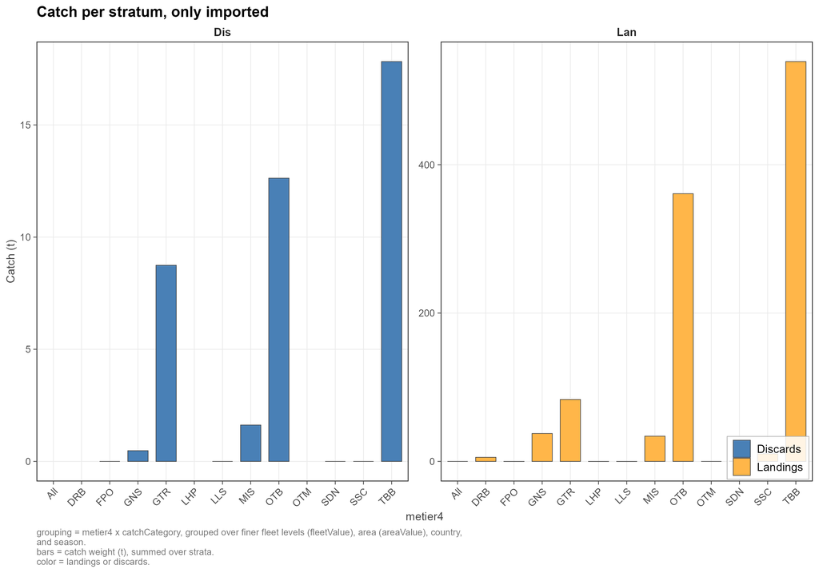

Figure 1: The catch as reported (only imported): the weight of the landings and of the discards by metier. File `discard_raising_01.png`.

> **Note on the length classes.** The length classes of the converted data are ten times too large: they run from 1,300 to 7,000 “mm” for a brill of 13 to 70 cm. InterCatch gives the lengths in millimetres; the conversion takes them for centimetres and multiplies them by ten. Every length below inherits it: the figures of the numbers and the mean weights at length read “cm” where the values are millimetres (a fish of 30 cm is drawn at 300), and so does the DC. It changes neither the numbers nor the weights. The converter should write the classes as they are before the DC is uploaded.

# 3 Discard raising

## 3.1 How the raising works

Discards are known only where somebody observed them, so only some of the strata that land brill have a discard estimate: about three quarters of the landings are in such strata (Figure 2). For the others the discards are *raised*: a landings row without a discard estimate gets a discards row equal to its landings times a **discard ratio** (discards divided by landings), taken from a group of comparable strata, its donors.

The comparable strata are written down by hand as **raising groups**. A group is a pair of conditions on the columns of the catch table:

- the **raising strata**: the landings that are raised together. A landing is in one group only: `check_group_conditions()` stops at a landing that falls in two groups and reports one that falls in none;
- the **matched data**: the strata whose landings and discards give the ratio of the group. They are often the raising strata themselves, but they can be a wider pool when the group has too little discard data of its own, and the pools of different groups may overlap.

The ratio is the total discards over the total landings of the donors that have a discard estimate, so the large strata weigh more. Everything else is kept as it came. The result of `catchRaising()` is the catch table with the raised discards added, each row marked `imported` or `raised` and carrying the name of its group.

## 3.2 Looking at the data to define the groups

The groups follow what the data say about where discards are observed and how large they are.

**Where are discards observed?** The beam trawls and the otter trawls, which land most of the brill, have most of their landings in strata with a discard estimate; many small fleets have none (Figure 2). Taken by gear group and mesh (Figure 3), most of the landings of the beam trawls (G1), the nets (G2) and the otter trawls (G3) are in tiles with at least half of the landings covered (green). The rest of the fleets (G4) are sparsely sampled and need the pool of all the others.

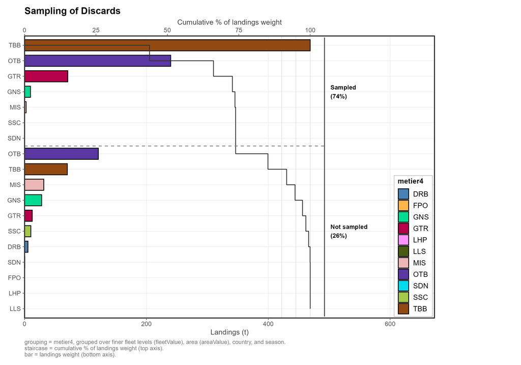

Figure 2: Sampling of the discards by metier: the landings of each metier (bars, bottom axis) and the cumulative share of the landings with a discard estimate (staircase, top axis); about three quarters of the landings are sampled. File `discard_raising_02.png`.

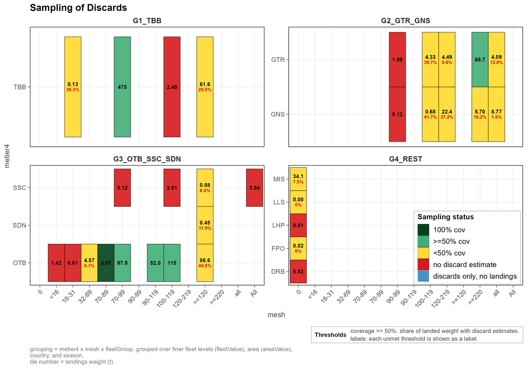

Figure 3: Sampling of the discards by fleet group, metier and mesh: the share of the landings with a discard estimate (green: at least 50%, yellow: less, red: none) and the landings in tonnes. File `discard_raising_04.png`.

**How large are they?** The discard ratio of the strata that were sampled is low and steady for the beam trawls and higher, and more scattered, for the nets and the otter trawls, where the few strata above 50% are nearly all in the Kattegat (27.3.a.21) (Figure 4).

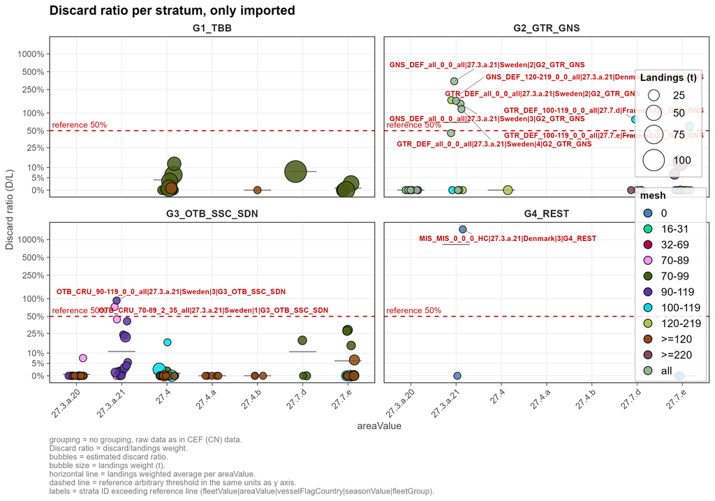

Figure 4: The discard ratio (discards over landings) of the strata that were sampled, by area, mesh (colour) and fleet group; the dashed line is 50%. File `discard_raising_06.png`.

**What explains them?** The strata were clustered by their discard rate, and the variables that best predict the cluster are the area, the mesh and the gear; the season is the weakest (Figure 5). Gear is the main axis of the groups, and the area is what the alternative below adds.

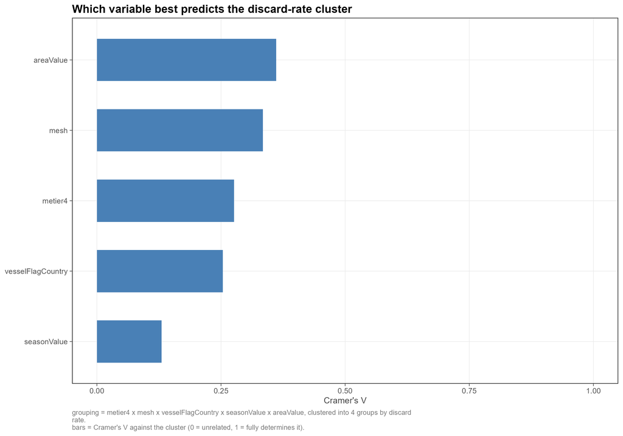

Figure 5: Which variable best predicts the discard-rate cluster of a stratum (Cramer’s V: 0 is unrelated, 1 determines it). File `discard_raising_08.png`.

## 3.3 The usual method

The usual method has five groups, by gear (Table 2). Here is the code of the script, `model_discard_raising.R`:

```r
strataCond <-
  list(G1_TBB = quo(metier4 == "TBB"),
       G2_GTR_GNS = quo(metier4 %in% c("GTR", "GNS")),
       G3_OTB_SSC_SDN = quo(metier4 %in% c("OTB", "SSC", "SDN") ),
       G4_REST = quo(!metier4 %in% c("TBB", "GTR", "GNS", "OTB", "SSC", "SDN") & fleetValue != "MIS_MIS_0_0_0_IBC"),
       G5_IBC = quo(fleetValue == "MIS_MIS_0_0_0_IBC" ))
```

```r
matchedDataCond <-
  list(G1_TBB = quo(metier4 == "TBB"),
       G2_GTR_GNS = quo(metier4 %in% c("GTR", "GNS")),
       G3_OTB_SSC_SDN = quo(metier4 %in% c("OTB", "SSC", "SDN")),
       ## REST group: too little discard data of its own, so it draws on ALL metier4 -- minus the strata with implausible discard ratios.
       G4_REST = quo(fleetValue != "MIS_MIS_0_0_0_IBC" & !Stratum %in% fleet_high_DR),
       G5_IBC = quo(fleetValue == "MIS_MIS_0_0_0_IBC"))
```

Table 2: The five groups of the usual method.

| Group | Raising strata | Donors | Why |
| --- | --- | --- | --- |
| G1_TBB | Beam trawls (TBB) | The same strata | Well sampled; a low and steady ratio. |
| G2_GTR_GNS | Gillnets and trammel nets (GNS, GTR) | The same strata | Sampled in part; the ratio differs from the others. |
| G3_OTB_SSC_SDN | Otter trawls and seines (OTB, SSC, SDN) | The same strata | Well sampled in part; the ratio varies with area and mesh. |
| G4_REST | All other metiers (dredges, pots, lines, unclassified), except the incidental bycatch fleet | All strata but the incidental bycatch, minus the strata whose own discard ratio is above 50% (the MIS metier excepted) | Too little discard data of its own: it draws on all the fleets, without the strata that look implausible. |
| G5_IBC | The incidental bycatch fleet (`MIS_MIS_0_0_0_IBC`) | The same strata | No landings: there is nothing to raise. |

The raising adds 16.9 t of discards to the 41.3 t that were reported, 58.2 t in all, of which 29% is raised (Table 3). The ratios the raised discards used are in the last column; Figure 6 shows them as crosses among the imported strata of their group.

Table 3: The usual method by group: the landings, the share of the landings whose discard domain has a discard estimate of the working group, the discards imported and raised (tonnes) and the discard ratio the raised discards used.

| Group | Landings (t) | With a discard estimate (%) | Discards imported (t) | Discards raised (t) | Ratio used (%) |
| --- | --- | --- | --- | --- | --- |
| G1_TBB | 539.0 | 87 | 17.8 | 2.7 | 3.8 |
| G2_GTR_GNS | 121.2 | 63 | 9.2 | 5.4 | 12.0 |
| G3_OTB_SSC_SDN | 371.7 | 65 | 12.6 | 6.9 | 5.3 |
| G4_REST | 39.6 | 0 | 1.6 | 2.0 | 5.0 |
| G5_IBC | 0.0 | - | 0.0 | 0.0 | - |
| Total | 1,071.6 | 73 | 41.3 | 16.9 | - |

The 24 raised rows of G5 have no donor and raise to nothing.

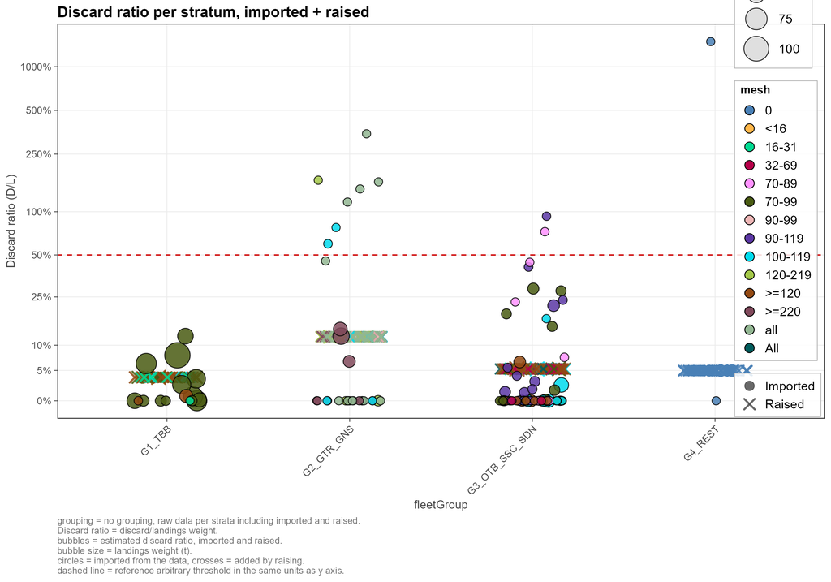

Figure 6: The discard ratio of every stratum after the usual raising, by group: circles are imported strata, crosses the raised ones. File `discard_raising_09.png`.

## 3.4 The alternative: the Kattegat on its own

The discard ratios of the nets and the otter trawls in the Kattegat (27.3.a.21) are much higher than elsewhere (Figure 4), and these fleets are well sampled there (Figure 7). In the alternative, called *usual method with 3.a.21*, the Kattegat strata of G2 and G3 are groups of their own, G2b and G3b, raised from the strata of the same gears in 27.3.a.21 only; the other groups are those of the usual method (Table 4).

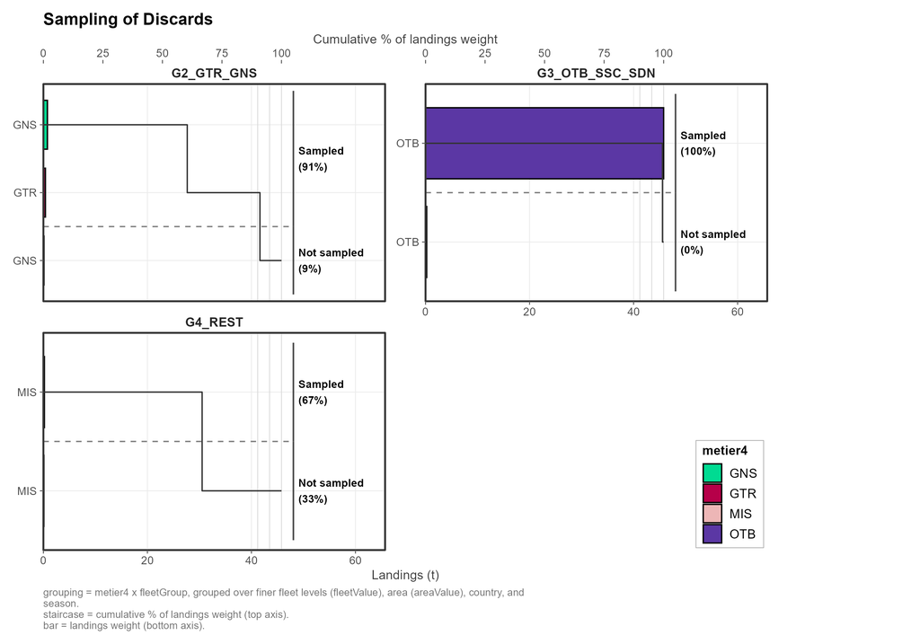

Figure 7: Sampling of the discards in the Kattegat (27.3.a.21), by fleet group. File `discard_raising_14.png`.

```r
strataCond <-
  list(G1_TBB             = quo(metier4 == "TBB"),
       G2_GTR_GNS         = quo(metier4 %in% c("GTR", "GNS") & areaValue != "27.3.a.21"),
       G2b_GTR_GNS_3a21   = quo(metier4 %in% c("GTR", "GNS") & areaValue == "27.3.a.21"),
       G3_OTB_SSC_SDN     = quo(metier4 %in% c("OTB", "SSC", "SDN") & areaValue != "27.3.a.21"),
       G3b_OTB_SSC_SDN_3a21 = quo(metier4 %in% c("OTB", "SSC", "SDN") & areaValue == "27.3.a.21"),
       G4_REST            = quo(!metier4 %in% c("TBB", "GTR", "GNS", "OTB", "SSC", "SDN") & fleetValue != "MIS_MIS_0_0_0_IBC"),
       G5_IBC             = quo(fleetValue == "MIS_MIS_0_0_0_IBC"))
```

```r
matchedDataCond <-
  list(G1_TBB             = quo(metier4 == "TBB"),
       G2_GTR_GNS         = quo(metier4 %in% c("GTR", "GNS") & areaValue != "27.3.a.21"),
       ## 27.3.a.21 raised independently: donors only from the same gears within 27.3.a.21
       G2b_GTR_GNS_3a21   = quo(metier4 %in% c("GTR", "GNS") & areaValue == "27.3.a.21"),
       G3_OTB_SSC_SDN     = quo(metier4 %in% c("OTB", "SSC", "SDN") & areaValue != "27.3.a.21"),
       G3b_OTB_SSC_SDN_3a21 = quo(metier4 %in% c("OTB", "SSC", "SDN") & areaValue == "27.3.a.21"),
       ## REST group: too little discard data of its own, so it draws on ALL metier4 -- minus the strata with implausible discard ratios.
       G4_REST            = quo(fleetValue != "MIS_MIS_0_0_0_IBC" & !Stratum %in% fleet_high_DR),
       G5_IBC             = quo(fleetValue == "MIS_MIS_0_0_0_IBC"))
```

Table 4: The groups of the alternative that differ from the usual method; G1, G4 and G5 are the same.

| Group | Raising strata | Donors | Why |
| --- | --- | --- | --- |
| G2_GTR_GNS | Nets outside 27.3.a.21 | The same strata | The ratio of the rest of the area. |
| G2b_GTR_GNS_3a21 | Nets in 27.3.a.21 | The same strata (27.3.a.21 only) | A higher ratio, well sampled. |
| G3_OTB_SSC_SDN | Otter trawls and seines outside 27.3.a.21 | The same strata | The ratio of the rest of the area. |
| G3b_OTB_SSC_SDN_3a21 | Otter trawls and seines in 27.3.a.21 | The same strata (27.3.a.21 only) | A higher ratio, well sampled. |

The strata of G2b and G3b are now raised at the level of their own sampled neighbours in the Kattegat, higher than the rest of their gear (Figure 8).

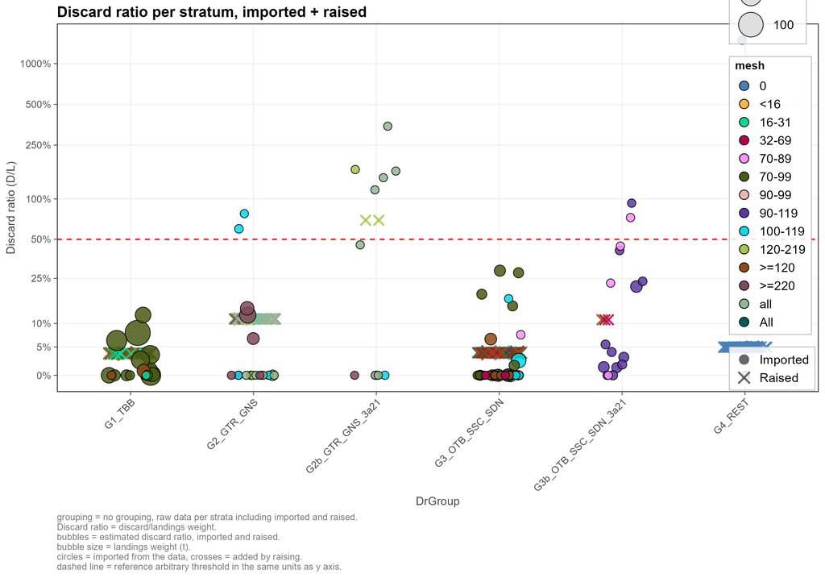

Figure 8: The discard ratio of every stratum after the alternative raising, by group: circles are imported strata, crosses the raised ones. File `discard_raising_18.png`.

## 3.5 The two methods compared

The two methods have the same imported catch. The alternative raises 14.8 t of discards instead of 16.9 t (-2.1 t, -12%), so the catch is 1,127.7 t instead of 1,129.8 t (Table 5). The difference lies in the otter trawls and, much less, the nets, the metiers the alternative splits (Figure 9).

Table 5: The two methods in tonnes: the catch imported, the discards raised and the total.

| Item | Usual method | Usual method with 3.a.21 | Difference |
| --- | --- | --- | --- |
| Landings (imported) | 1,071.6 | 1,071.6 | 0.0 |
| Discards imported | 41.3 | 41.3 | 0.0 |
| Discards raised | 16.9 | 14.8 | -2.1 |
| Total catch | 1,129.8 | 1,127.7 | -2.1 |

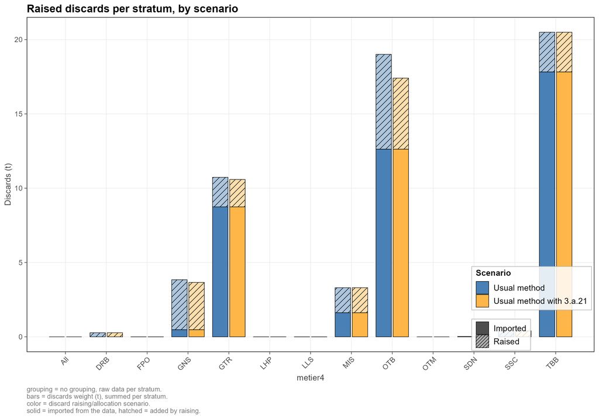

Figure 9: The discards raised and imported by metier, for the two methods: colour is the method, solid is imported and hatched is raised. File `discard_raising_20.png`.

The CC and the DC below are made from the usual method: it is the raising that `model_discard_raising.R` saves in `model/catch_data_raised.csv`, which the aggregation reads. The alternative is kept as a comparison.

# 4 Length allocation

## 4.1 How the allocation works

After the raising every stratum has a catch weight, but a length distribution only if somebody measured fish in it: there are 54 length distributions, with 7,952 fish measured in all. The **allocation** gives every stratum one. A stratum that has a sampled distribution keeps it. One that has none gets one estimated from its group: the numbers at length of the pooled donors, scaled by the weight of the stratum’s catch over the weight of the catch that was sampled, and the mean weight at length of the donors, averaged with the numbers at that length as weights. The estimated distributions are marked as such (`sampledOrEstimated`).

The allocation works with **groups** as the raising does: the *allocation strata*, which are allocated together and must not overlap, and the *matched data*, the sampled distributions the group takes its shape from, which can be a wider pool. `check_group_conditions()` checks the groups before anything is allocated. The discards are smaller fish than the landings and have their own length distributions, so landings and discards are allocated in groups apart.

## 4.2 Where are the length samples?

Most of the landings of the beam trawls and about half of those of the nets have a length distribution, against a third of the otter trawls and almost nothing for the rest (Figure 10). For the discards only the beam trawls are well sampled (Figure 11). The thresholds of Figure 12, at least half of the landings covered and at least 100 fish measured, are cleared by the beam trawls with a mesh of 70-99 mm and by the nets of 220 mm and over, so those two groups can be allocated on their own samples.

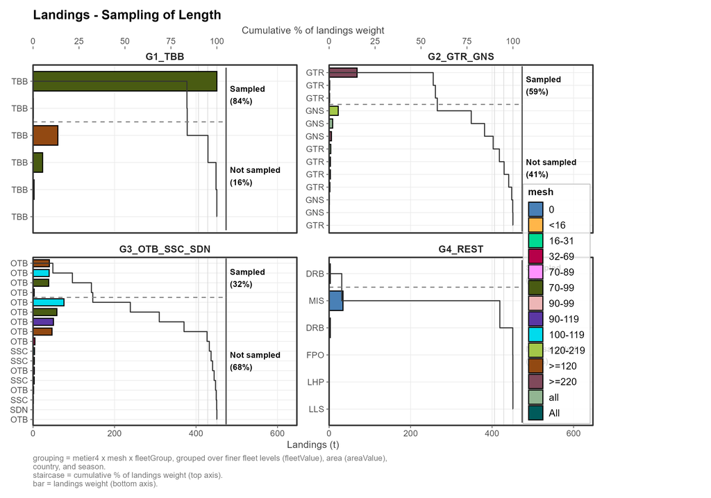

Figure 10: Sampling of length in the landings, by fleet group: the landings by metier and mesh (bars) and the cumulative share with a length distribution (staircase). File `length_allocation_02.png`.

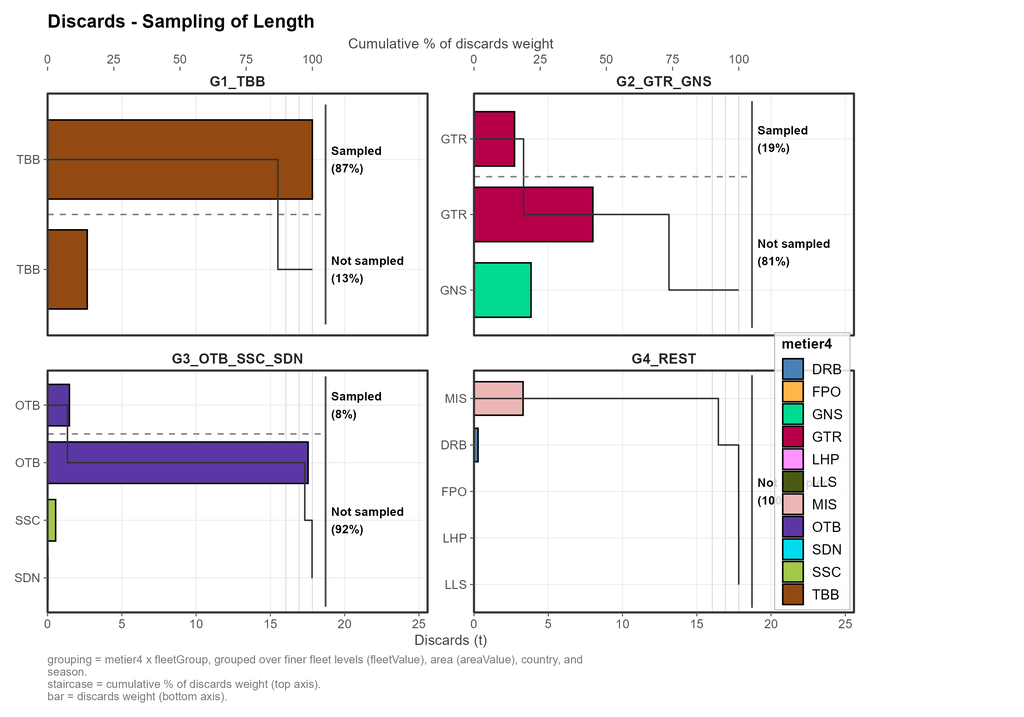

Figure 11: Sampling of length in the discards, by fleet group. File `length_allocation_14.png`.

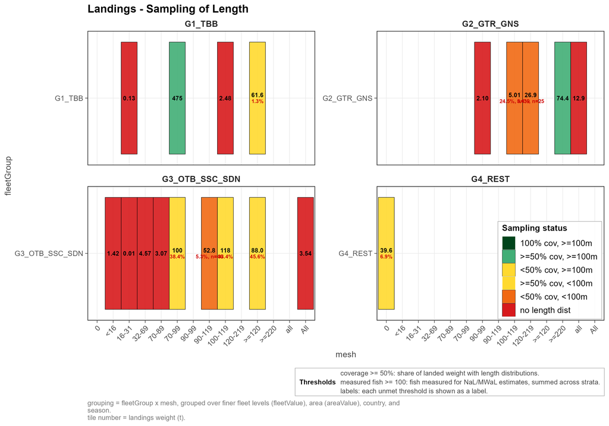

Figure 12: Sampling of length in the landings by fleet group and mesh against two thresholds: at least 50% of the landings with a length distribution and at least 100 fish measured. File `length_allocation_04.png`.

## 4.3 The groups

There are six groups (Table 6), written in `model_length_allocation.R`:

```r
allocStrataCond <-
  list(G1_TBB_LAN = quo(catchCategory == "Lan" & metier4 == "TBB"),

       G2_GTR_GNS_LAN = quo(catchCategory == "Lan" & metier4 %in% c("GTR", "GNS")),

       G3_REST_LAN = quo(catchCategory == "Lan" & !metier4 %in% c("TBB", "GTR", "GNS") &
                   fleetValue != "MIS_MIS_0_0_0_IBC"),

       ## TBB discards get their own length distribution:
       G4_TBB_DIS = quo(catchCategory == "Dis" & metier4 == "TBB"),

       ## All other discards + all BMS, allocated together:
       G5_REST_DIS = quo(catchCategory %in% c("Dis", "BMS") &
                   !(catchCategory == "Dis" & metier4 == "TBB") &
                   fleetValue != "MIS_MIS_0_0_0_IBC"),

       G6_IBC = quo(fleetValue == "MIS_MIS_0_0_0_IBC"))
```

```r
bioMatchedCond <-
  list(G1_TBB_LAN = quo(catchCategory == "Lan" & metier4 == "TBB"),
       G2_GTR_GNS_LAN = quo(catchCategory == "Lan" & metier4 %in% c("GTR", "GNS")),
       G3_REST_LAN = quo(catchCategory == "Lan"),
       ## TBB discards: TBB discard samples only
       G4_TBB_DIS = quo(catchCategory == "Dis" & metier4 == "TBB"),
       ## Other discards + BMS: ALL discard samples, TBB INCLUDED
       ## (GA4's donors are a subset of GA5's, like GA1/GA2 within GA3):
       G5_REST_DIS = quo(catchCategory %in% c("Dis", "BMS")),
       G6_IBC = quo(catchCategory %in% c("Lan", "Dis", "BMS")))
```

Table 6: The six allocation groups.

| Group | Allocation strata | Donors | Why |
| --- | --- | --- | --- |
| G1_TBB_LAN | Landings of the beam trawls | The same strata | Enough samples (coverage and fish measured) in its main mesh: its own distribution. |
| G2_GTR_GNS_LAN | Landings of the nets | The same strata | Enough samples in its main mesh: its own distribution. |
| G3_REST_LAN | Landings of the other metiers | All the landings | Too little sampled: it draws on all the landings. |
| G4_TBB_DIS | Discards of the beam trawls | The same strata | Well sampled: its own distribution. |
| G5_REST_DIS | The other discards and the BMS | All the discards and the BMS, beam trawls included | Too little sampled: it draws on all the discards. |
| G6_IBC | The incidental bycatch fleet, all catch categories | All the samples | No catch: nothing to allocate. |

## 4.4 What the allocation did

Every catch row got a distribution (none is left without one): 54 distributions are sampled and 1,232 were estimated. By weight, 60% of the landings and 38% of the discards have a sampled distribution; the rest takes the shape of its donors (Table 7).

Table 7: The allocation by group: the distributions that are sampled or estimated, and the catch (tonnes) they belong to.

| Group | Catch rows | Sampled distributions | Estimated distributions | Catch with a sampled distribution (t) | Catch with an estimated distribution (t) | Sampled (%) |
| --- | --- | --- | --- | --- | --- | --- |
| G1_TBB_LAN | 71 | 14 | 57 | 452.0 | 87.0 | 84 |
| G2_GTR_GNS_LAN | 142 | 6 | 136 | 71.3 | 49.9 | 59 |
| G3_REST_LAN | 406 | 22 | 384 | 123.5 | 287.8 | 30 |
| G4_TBB_DIS | 71 | 8 | 63 | 17.8 | 2.7 | 87 |
| G5_REST_DIS | 548 | 4 | 544 | 4.2 | 33.5 | 11 |
| G6_IBC | 48 | 0 | 48 | 0.0 | 0.0 | - |
| Total | 1,286 | 54 | 1,232 | 668.9 | 461.0 | 59 |

The numbers at length of the landings show the groups: the beam trawls land fish of 30 to 40 cm, the nets fish around 50 cm, and the other gears a broad range; where no samples were taken the distribution is estimated (hatched) from the donors and scaled to the landings of the stratum (Figure 13). The discards are smaller fish, and only the beam trawls have sampled distributions of their own (Figure 14). The length axes of the figures read cm for what is millimetres (see the note in the data section).

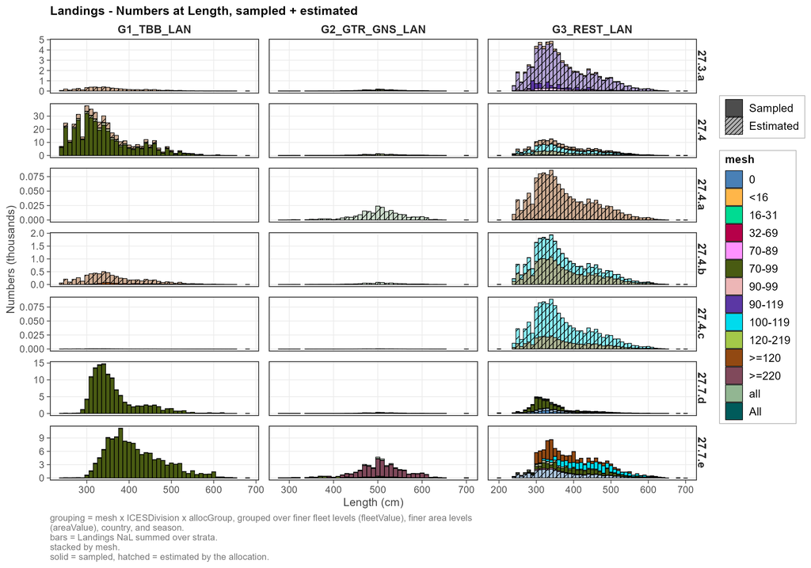

Figure 13: Numbers at length of the landings, by ICES division (rows) and allocation group (columns), filled by mesh: solid is sampled, hatched is estimated by the allocation. File `length_allocation_22.png`.

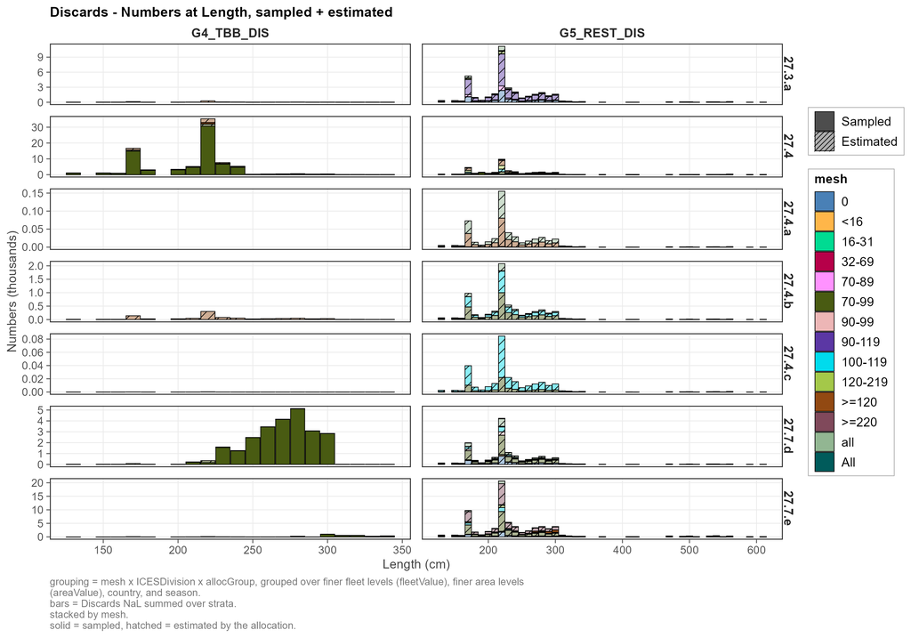

Figure 14: Numbers at length of the discards, by ICES division (rows) and allocation group (columns), filled by mesh: solid is sampled, hatched is estimated. File `length_allocation_25.png`.

The mean weight at length of the estimated distributions follows that of the sampled ones (Figure 15): the allocation keeps the relation between length and weight of each group.

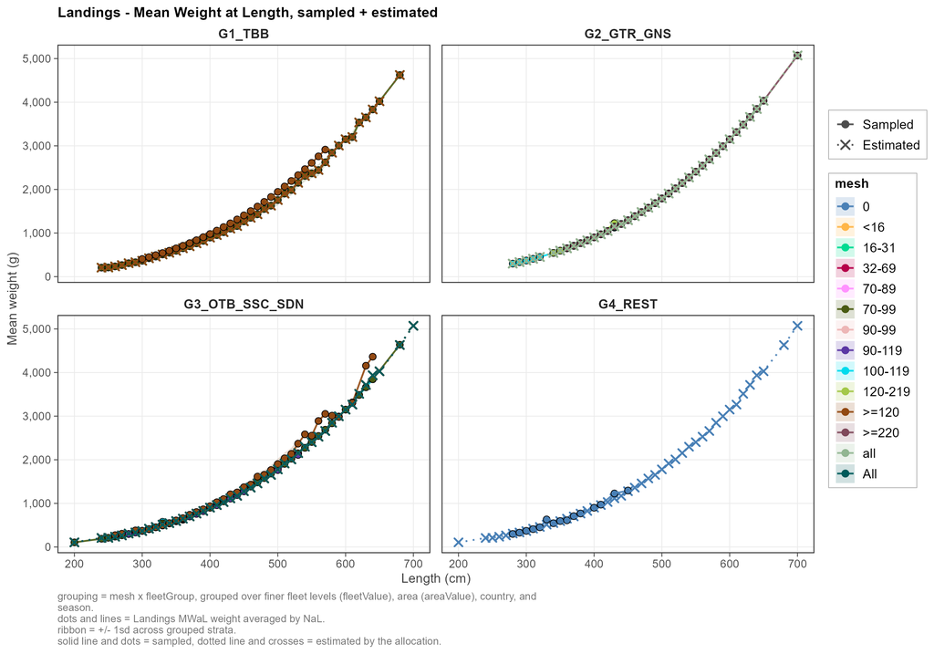

Figure 15: Mean weight at length of the landings, by fleet group and mesh (colour): dots and a solid line are sampled, crosses and a dotted line are estimated by the allocation. File `length_allocation_27.png`.

# 5 Aggregation and the two final tables

## 5.1 The aggregation functions

The two final tables are made by `catchCombined()` and `distributionsCombined()` of `rcef`, in `output.R`. Both add up over the strata and take the same `grouping`: the year, the working group and the stock, the catch category, and what else the stock assessment asks for. Here the catch is not split further, so the grouping is the catch category. If the assessment asks for the catch by season, area or fleet, these are added to the `grouping` of both functions, since every distribution needs the catch it belongs to in the CC.

**`catchCombined()`** adds up the working group’s catch (`originType_catch = "WGEstimate"`, weights) of the raised catch, in tonnes, by catch category, and writes the header of the file: the version and its description, whether the year is the calendar year and, if it is not, the day the model year starts. A raised row with no ratio (no donor) adds up as nothing.

**`distributionsCombined()`** takes the distributions of the allocation. It links each distribution to the catch it describes through its domain: a sampled one through `domainBiology`, an estimated one through the domain the allocation made up for the stratum (a name that starts with `[alloc]_`), so every stratum, raised or not, sampled or estimated, finds its distribution. The numbers at length are added up over all the strata of the category, in thousands of fish (unit `NE3`), and the mean weight at length is the average of the strata’s mean weights, in g, weighted by their numbers at that length (`weighting = "NumberAtAoL"`). The result has the long format of the SCF: for each length class a `Number` row (value type `Total`) and a `WeightLive` row (value type `Mean`); a class with no fish is left out. The function warns when it finds a catch weight with no distribution, or a distribution with fish and no catch weight.

```r
CatchCombined <-
  catchCombined(catch_data = catch_data_raised,
                grouping = c("catchCategory"),
                originType_catch = "WGEstimate",
                variableType_catch = "WeightLive",
                unit = "t",
                round = 6,
                version = version,
                versionDescription = versionDescription,
                calendarYear = calendarYear,
                yearStartDate = yearStartDate)
```

```r
DistributionsCombined <-
  distributionsCombined(distribution_data = distributions_data_allocated,
                        catch_data = catch_data_raised,
                        grouping = c( "attributeType", "attributeValue"),
                        weighting = "NumberAtAoL",
                        originType_catch = "WGEstimate",
                        variableType_catch = "WeightLive",
                        distributionType = "LengthTotal",
                        unit = c("NE3", "g"),
                        round = 6,
                        version = version,
                        versionDescription = versionDescription,
                        calendarYear = calendarYear,
                        yearStartDate = yearStartDate)
```

The same numbers can be had with one column per length class (`catchAtAoLAggregation()` and `meanWoLatAoLAggregation()`, also in `output.R`) for a look; they are not part of the SCF.

## 5.2 Catch Combined

The CC has one row per catch category (Table 8): 1,071.6 t of landings and 58.2 t of discards, 1,129.8 t in all. The row of the landings below the minimum size (BMS) is 0.0 t. The fields of the SCF that the catch is not split by (season, area, fleet), the variance and the trips are empty.

Table 8: The Catch Combined (`output/SCF_CC.csv`): one column for each row of the file, named by its catch category, with the fields that are filled; the others are empty.

| Field | BMS | Dis | Lan |
| --- | --- | --- | --- |
| recordType | CC | CC | CC |
| version | 1 | 1 | 1 |
| versionDescription | WGNSSK 2026 first run discard raising | WGNSSK 2026 first run discard raising | WGNSSK 2026 first run discard raising |
| calendarYear | Y | Y | Y |
| year | 2025 | 2025 | 2025 |
| workingGroup | WGNSSK | WGNSSK | WGNSSK |
| stock | bll.27.3a47de | bll.27.3a47de | bll.27.3a47de |
| variableType | WeightLive | WeightLive | WeightLive |
| variableUnit | t | t | t |
| total | 0.0 | 58.2 | 1,071.6 |

## 5.3 Distributions Combined

The DC has 158 rows: 45 length classes for the landings and 34 for the discards, each with a `Number` row and a `WeightLive` row (Table 9). Figure 16 draws it: the numbers at length, in thousands of fish, and the mean weight at length, in g, for the landings and the discards. The classes in the file are ten times larger than the lengths in the figure (see the note in the data section).

Table 9: The Distributions Combined (`output/SCF_DC.csv`): the first two length classes of each catch category, a `Number` row (thousands of fish, `NE3`) and a `WeightLive` row (mean weight, g) for each. All rows have the distribution type `LengthTotal`, in mm; the other fields are empty.

| catchCategory | distributionClass | variableType | variableUnit | valueType | value |
| --- | --- | --- | --- | --- | --- |
| Dis | 1,300 | WeightLive | g | Mean | 32.060 |
| Dis | 1,300 | Number | NE3 | Total | 2.622 |
| Dis | 1,500 | WeightLive | g | Mean | 48.780 |
| Dis | 1,500 | Number | NE3 | Total | 2.622 |
| Lan | 2,000 | WeightLive | g | Mean | 105.680 |
| Lan | 2,000 | Number | NE3 | Total | 0.225 |
| Lan | 2,400 | WeightLive | g | Mean | 206.862 |
| Lan | 2,400 | Number | NE3 | Total | 9.938 |

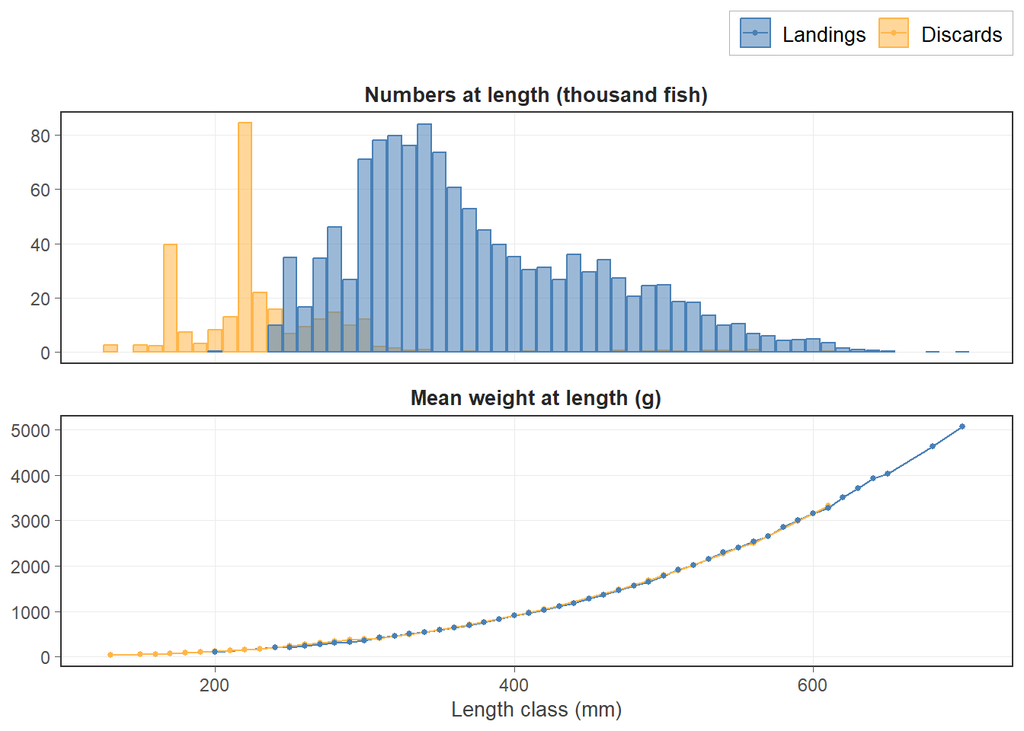

Figure 16: The Distributions Combined: the numbers at length (thousands of fish) and the mean weight at length (g) of the landings and of the discards.

## 5.4 The check before uploading

The SCF compares the catch of the CC with the sum of products of the DC (the numbers times the mean weights, over the classes) and rejects a total more than 20% off. Here the two are at most 0.9% apart (Table 10).

Table 10: The check of the SCF: the sum of products of the DC against the catch of the CC.

| Catch category | Sum of products of the DC (t) | Catch of the CC (t) | Sum of products over catch |
| --- | --- | --- | --- |
| Dis | 58.4 | 58.2 | 1.003 |
| Lan | 1,062.0 | 1,071.6 | 0.991 |

The two files are `output/SCF_CC.csv` (3 rows) and `output/SCF_DC.csv` (158 rows). Empty fields are left empty, and the two are uploaded together. The length classes of the DC are the ten times too large ones of the converted data (see the note in the data section): they should be corrected at the source, and the steps run again, before the upload.

# 6 How this report is made

`report.R` renders `report.qmd` to html and pdf in `report/`. The report reads the files the other scripts leave (`data/`, `model/`, `output/`) and shows the figures they saved in `output/figures/`; it draws only the last figure and computes only the small tables. The scripts are run in this order: `data.R`, `model_discard_raising.R`, `model_length_allocation.R`, `output.R` and then `report.R`. A figure or a table is as current as the script that made its file.